# Analysis of Residuals of a Linear Model

Yuanyuan Pan

October 23, 2016

## Analysis of Residuals of a Linear Model

This project helps understanding analysis of residuals of the estimated linear model

### Case 1

```r
datapath<- getwd()
LinearModelData<-read.csv(file=paste(datapath,"LinearModelCase1.csv",sep="/"))
head(LinearModelData)
```

```
##      Input   Output
## 1 3.132859 1.988783
## 2 5.561134 3.239651
## 3 1.984543 1.400981
## 4 5.619160 4.358627
## 5 6.378149 4.311206
## 6 6.123204 3.227389
```

Plot the data

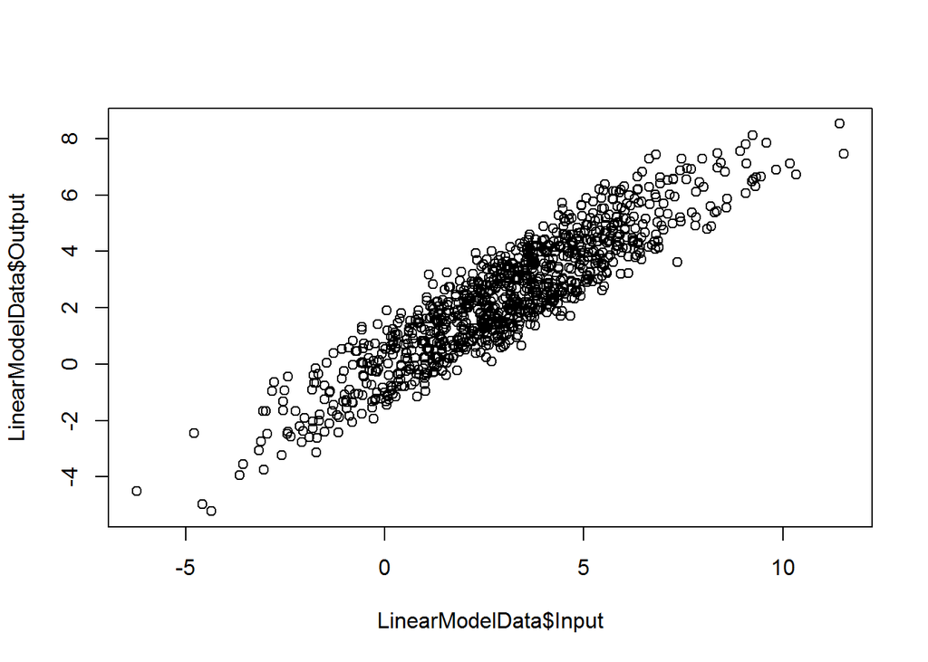

```r
plot(LinearModelData$Input,LinearModelData$Output)
```

Estimate linear model using function `lm()` look at the output of the function

```r
Estimated.LinearModel <- lm(Output ~ Input,data=LinearModelData)
names(Estimated.LinearModel)
```

```
##  [1] "coefficients"  "residuals"     "effects"       "rank"
##  [5] "fitted.values" "assign"        "qr"            "df.residual"
##  [9] "xlevels"       "call"          "terms"         "model"
```

#### Coefficients

```r
Estimated.LinearModel$coefficients
```

```
## (Intercept)       Input
## -0.01017199  0.78465209
```

#### Residual plot

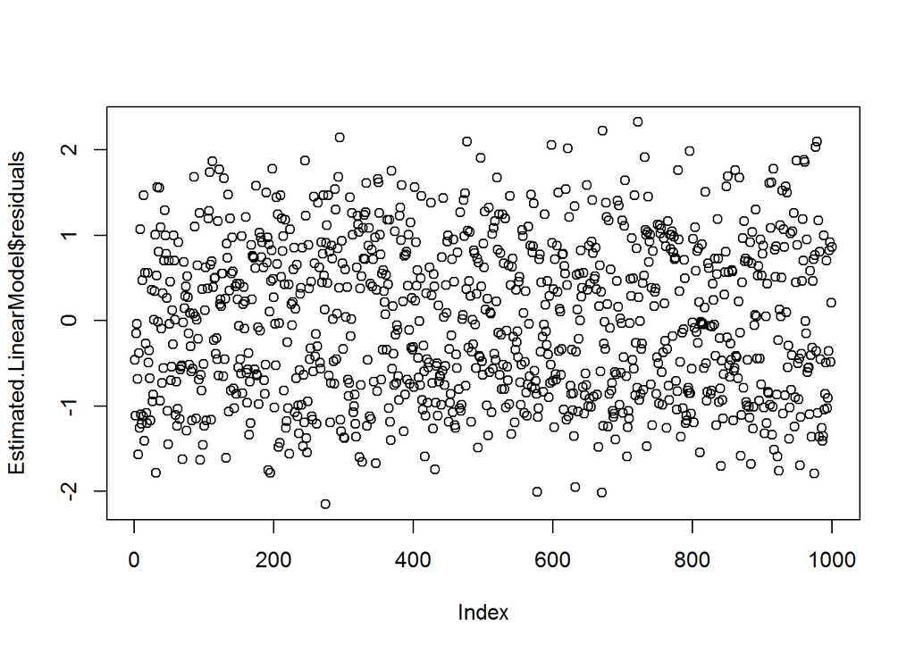

```r
plot(Estimated.LinearModel$residuals)
```

#### find out what `fitted.values`

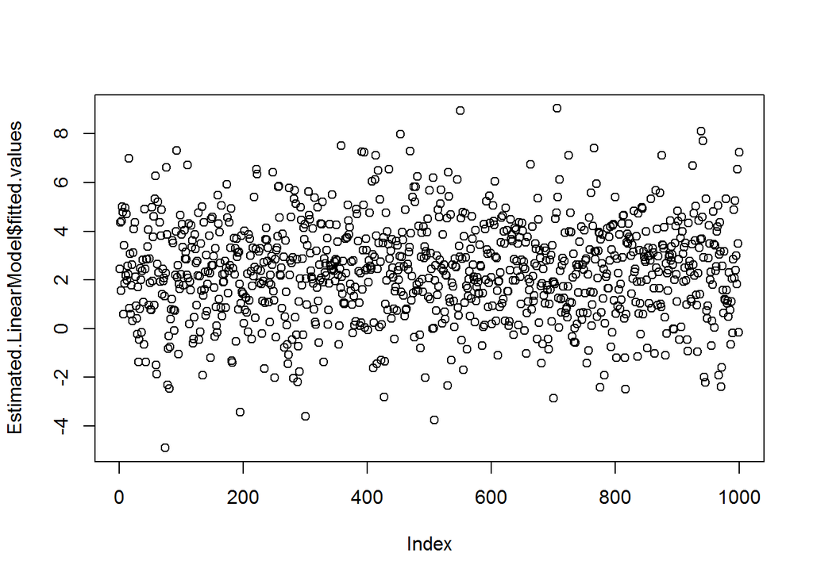

```r
plot(Estimated.LinearModel$fitted.values)
```

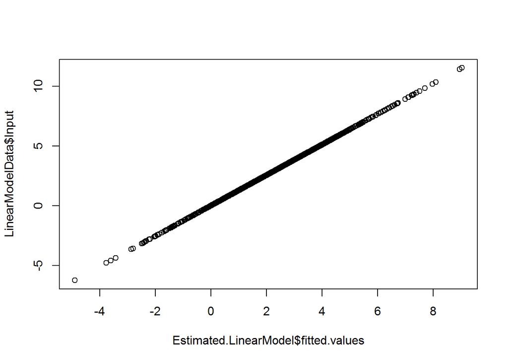

```r
plot(Estimated.LinearModel$fitted.values, LinearModelData$Input)
```

`Fitted.value` is the estimated/predicted value of the output.

Look at the Summary

```r
summary(Estimated.LinearModel)
```

```
##
## Call:
## lm(formula = Output ~ Input, data = LinearModelData)
##
## Residuals:
##      Min       1Q   Median       3Q      Max
## -2.15287 -0.76836 -0.02845  0.73511  2.32755
##
## Coefficients:
##             Estimate Std. Error t value Pr(>|t|)
## (Intercept) -0.01017    0.04531  -0.225    0.822
## Input        0.78465    0.01152  68.142   <2e-16 ***
## ---
## Signif. codes:  0 '***' 0.001 '**' 0.01 '*' 0.05 '.' 0.1 ' ' 1
##
## Residual standard error: 0.9168 on 998 degrees of freedom
## Multiple R-squared:  0.8231, Adjusted R-squared:  0.8229
## F-statistic:  4643 on 1 and 998 DF,  p-value: < 2.2e-16
```

#### Interpret the summary

```r
names(summary(Estimated.LinearModel))
```

```
##  [1] "call"          "terms"         "residuals"     "coefficients"
##  [5] "aliased"       "sigma"         "df"            "r.squared"
##  [9] "adj.r.squared" "fstatistic"    "cov.unscaled"
```

`summary(Estimated.LinearModel)$sigma` is the estimated standard deviation of the randon variable in linear regression model.

```r
summary(Estimated.LinearModel)$sigma
```

```
## [1] 0.916792
```

```r
summary(Estimated.LinearModel)$sigma^2
```

```
## [1] 0.8405075
```

#### Check Process

```r
sigmaSquared.byVar <- var(Estimated.LinearModel$residuals)*(length(LinearModelData[,1])-1)/(length(LinearModelData[,1])-2)
sigmaSquared.bySum <- sum(Estimated.LinearModel$residuals^2)/(length(Estimated.LinearModel$residuals)-2)
c(sigmaSquared.byVar=sigmaSquared.byVar,sigmaSquared.bySum=sigmaSquared.bySum,fromModel=summary(Estimated.LinearModel)$sigma^2)
```

```
## sigmaSquared.byVar sigmaSquared.bySum          fromModel
##          0.8405075          0.8405075          0.8405075
```

Observe the residuals, plot them against the input, , and their probability density in comparison with the normal density

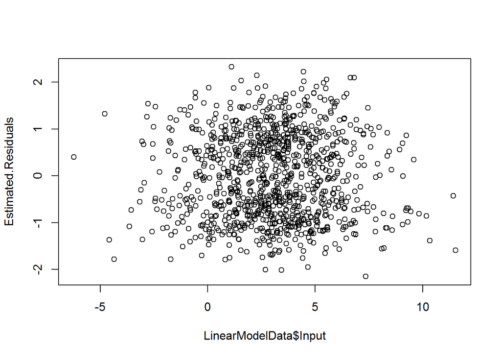

```r
Estimated.Residuals <- Estimated.LinearModel$residuals
plot(LinearModelData$Input, Estimated.Residuals)
```

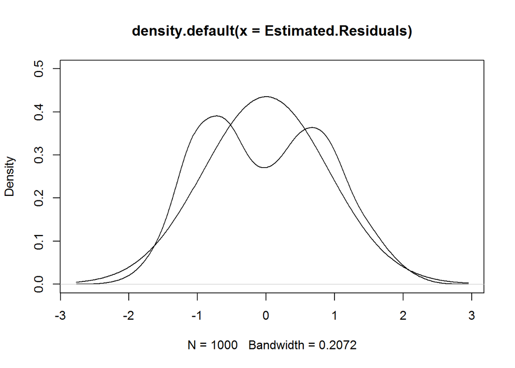

```r
Probability.Density.Residuals <- density(Estimated.Residuals)
plot(Probability.Density.Residuals, ylim = c(0, 0.5))
lines(Probability.Density.Residuals$x, dnorm(Probability.Density.Residuals$x,
    mean = mean(Estimated.Residuals), sd = sd(Estimated.Residuals)))
```

From the analysis of residuals, we can see there is a gap in the middle of two peak of the density curve, which means the residual could be from a combination of two normal distribution with different mean.

```r
c(Left.Mean = mean(Estimated.Residuals[Estimated.Residuals < 0]),
  Right.Mean = mean(Estimated.Residuals[Estimated.Residuals > 0]))
```

```
##  Left.Mean Right.Mean
## -0.7757368  0.8073995
```

Separate the given sample into 2 subsamples: one, for which the residuals are below zero and another, for which they are above zero. Create variable `Unscrambled.Selection.Sequence` estimating switching between the two subsamples (1 corresponds to the positive residual case and 0 corresponds to the negative residual case).

```r
Unscrambled.Selection.Sequence <- as.numeric(Estimated.LinearModel$residuals >0)

head(Unscrambled.Selection.Sequence,30)
```

```
##  [1] 0 0 0 0 0 0 0 0 1 0 0 1 0 1 0 1 0 0 0 1 0 0 0 0 1 0 0 1 1 1
```

Matrix `LinearModel1.Recovered` contains all rows of the original data for which residuals are greater than zero. Matrix `LinearModel2.Recovered` contains all rows of the original data for which residuals are less than zero.

```r
LinearModel1.Recovered <- LinearModelData
LinearModel1.Recovered[Unscrambled.Selection.Sequence == 0,] <-  NA
LinearModel2.Recovered <- LinearModelData
LinearModel2.Recovered[Unscrambled.Selection.Sequence == 1,] <-  NA

head(cbind(LinearModel1.Recovered,LinearModel2.Recovered),30)
```

```
##         Input    Output     Input      Output
## 1          NA        NA 3.1328589  1.98878260
## 2          NA        NA 5.5611337  3.23965071
## 3          NA        NA 1.9845429  1.40098090
## 4          NA        NA 5.6191601  4.35862661
## 5          NA        NA 6.3781486  4.31120588
## 6          NA        NA 6.1232040  3.22738908
## 7          NA        NA 0.7666195  0.21326715
## 8          NA        NA 4.3535141  2.14572453
## 9   2.3627156 2.9156983        NA          NA
## 10         NA        NA 6.3272368  3.85671346
## 11         NA        NA 2.7794196  0.95715347
## 12  6.0030759 5.1762674        NA          NA
## 13         NA        NA 2.5360972  0.86111904
## 14  3.2869489 4.0377583        NA          NA
```

[output cut: 16 more lines]

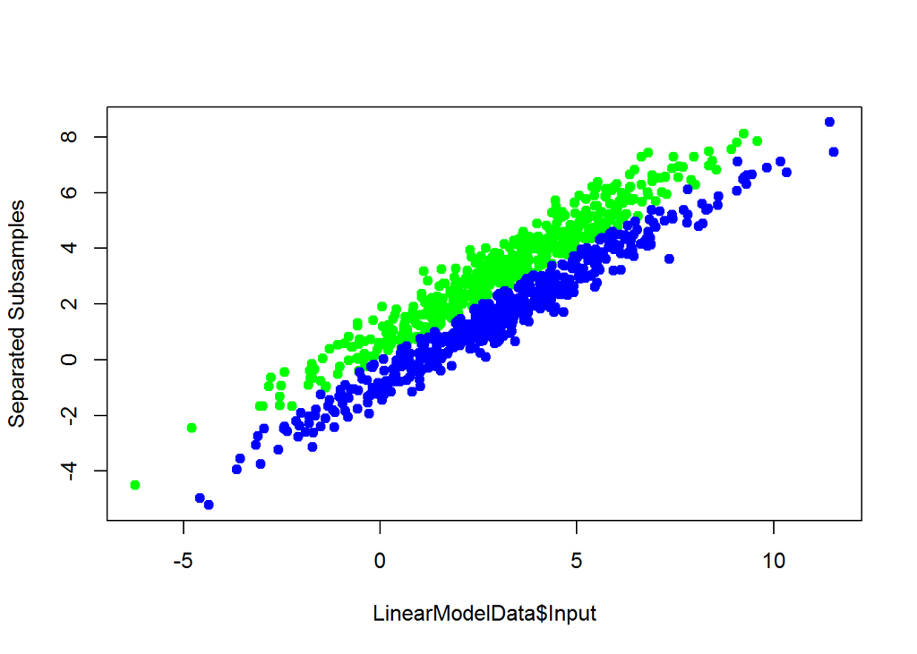

```r
#Plot two clusters
matplot(LinearModelData$Input, cbind(LinearModel1.Recovered[, 2], LinearModel2.Recovered[,2]),
        type = "p", col = c("green", "blue"), pch = 19, ylab = "Separated Subsamples")
```

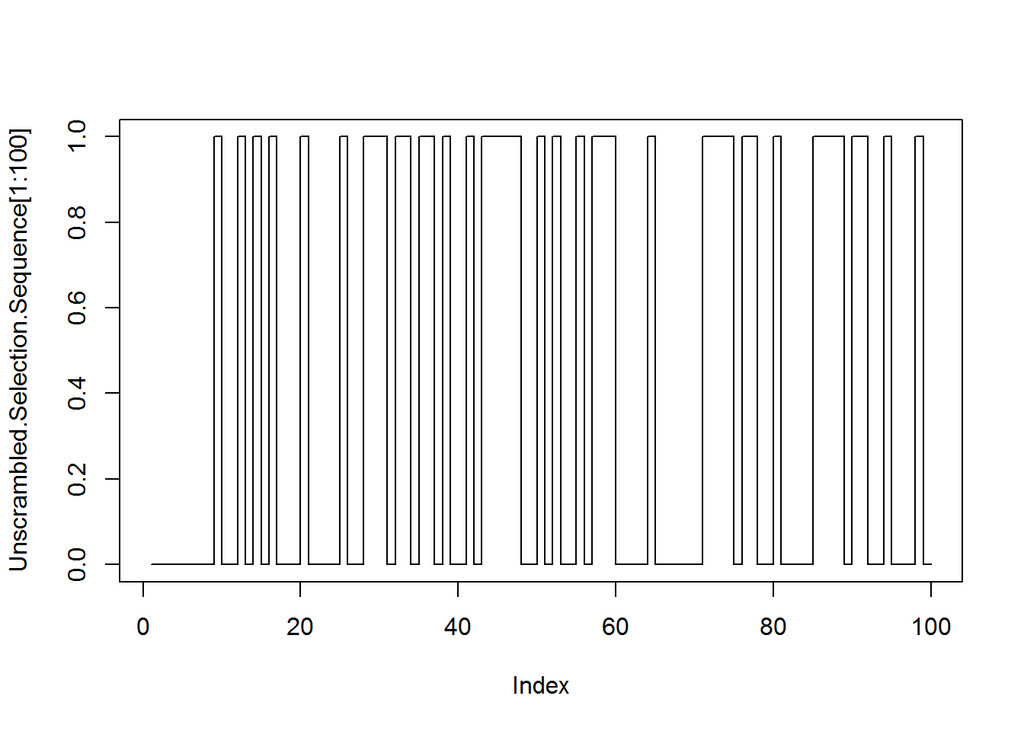

```r
plot(Unscrambled.Selection.Sequence[1:100], type = "s")
```

Now estimate the linear models from the subsamples.

```r
LinearModel1.Recovered.lm <- lm(Output ~ Input, data = na.omit(LinearModel1.Recovered))
LinearModel2.Recovered.lm <- lm(Output ~ Input, data = na.omit(LinearModel2.Recovered))
```

Compare the results of fitting of the first recovered linear model:

```r
summary(LinearModel1.Recovered.lm)$coefficients
```

```
##              Estimate  Std. Error  t value      Pr(>|t|)
## (Intercept) 0.7793033 0.035219952 22.12676  1.209545e-75
## Input       0.7906129 0.009146933 86.43476 5.452384e-298
```

```r
summary(LinearModel1.Recovered.lm)$sigma
```

```
## [1] 0.4869543
```

```r
summary(LinearModel1.Recovered.lm)$df
```

```
## [1]   2 488   2
```

```r
summary(LinearModel1.Recovered.lm)$r.squared
```

```
## [1] 0.9386855
```

```r
summary(LinearModel1.Recovered.lm)$adj.r.squared
```

```
## [1] 0.9385599
```

```r
summary(LinearModel2.Recovered.lm)$coefficients
```

```
##               Estimate  Std. Error  t value     Pr(>|t|)
## (Intercept) -0.7823421 0.029576586 -26.4514 1.382402e-97
## Input        0.7834786 0.007369122 106.3191 0.000000e+00
```

```r
summary(LinearModel2.Recovered.lm)$sigma
```

```
## [1] 0.4362393
```

```r
summary(LinearModel2.Recovered.lm)$df
```

```
## [1]   2 508   2
```

```r
summary(LinearModel2.Recovered.lm)$r.squared
```

```
## [1] 0.956992
```

```r
summary(LinearModel2.Recovered.lm)$adj.r.squared
```

```
## [1] 0.9569073
```

with the summary of the fit to the whole sample.

The sigma parameters:

```r
c(summary(Estimated.LinearModel)$sigma,
  summary(LinearModel1.Recovered.lm)$sigma,
  summary(LinearModel2.Recovered.lm)$sigma)
```

```
## [1] 0.9167920 0.4869543 0.4362393
```

The $\rho^2$:

```r
c(summary(Estimated.LinearModel)$r.squared,
  summary(LinearModel1.Recovered.lm)$r.squared,
  summary(LinearModel2.Recovered.lm)$r.squared)
```

```
## [1] 0.8230895 0.9386855 0.9569920
```

The F-statistics:

```r
rbind(LinearModel=summary(Estimated.LinearModel)$fstatistic,
      LinearModel1.Recovered=summary(LinearModel1.Recovered.lm)$fstatistic,
      LinearModel2.Recovered=summary(LinearModel2.Recovered.lm)$fstatistic)
```

```
##                            value numdf dendf
## LinearModel             4643.272     1   998
## LinearModel1.Recovered  7470.967     1   488
## LinearModel2.Recovered 11303.757     1   508
```

Here is how we can calculate p-values of F-test using cumulative probability function of F-distribution:

```r
c(LinearModel=pf(summary(Estimated.LinearModel)$fstatistic[1],
                 summary(Estimated.LinearModel)$fstatistic[2],
                 summary(Estimated.LinearModel)$fstatistic[3],lower.tail = FALSE),
  LinearModel1.Recovered=pf(summary(LinearModel1.Recovered.lm)$fstatistic[1],
                            summary(LinearModel1.Recovered.lm)$fstatistic[2],
                            summary(LinearModel1.Recovered.lm)$fstatistic[3],lower.tail = FALSE),
  LinearModel2.Recovered=pf(summary(LinearModel2.Recovered.lm)$fstatistic[1],
                            summary(LinearModel2.Recovered.lm)$fstatistic[2],
                            summary(LinearModel2.Recovered.lm)$fstatistic[3],lower.tail = FALSE))
```

```
##            LinearModel.value LinearModel1.Recovered.value
##                 0.000000e+00                5.452384e-298
## LinearModel2.Recovered.value
##                 0.000000e+00
```

The numbers may not look exactly the same as in `summary()` because of the precision limitation.

Compare the combined residuals of the two separated models with the residuals of `Estimated.LinearModel`

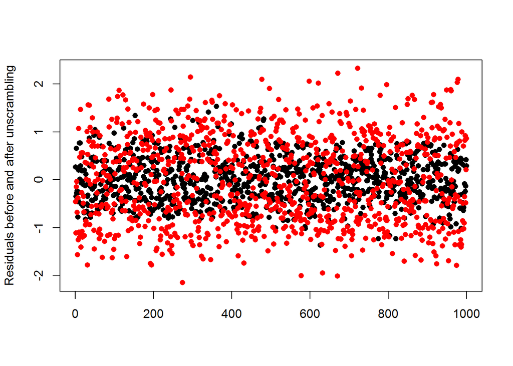

```r
# Plot residuals
matplot(cbind(MixedModel.residuals=c(summary(LinearModel1.Recovered.lm)$residuals,
                                     summary(LinearModel2.Recovered.lm)$residuals),
              Single.Model.residuals=summary(Estimated.LinearModel)$residuals),
        type="p",pch=16,ylab="Residuals before and after unscrambling")
```

```r
# Estimate standard deviations
apply(cbind(MixedModel.residuals=c(summary(LinearModel1.Recovered.lm)$residuals,
                                   summary(LinearModel2.Recovered.lm)$residuals),
            Single.Model.residuals=summary(Estimated.LinearModel)$residuals),2,sd)
```

```
##   MixedModel.residuals Single.Model.residuals
##              0.4610902              0.9163330
```

The MixedModel model has much lower variance of residual, with better fitness.

The difference between the two estimated models are

- Single Model has only one group of parameters, while Mixed Model has two groups of parameters.
- Single Model has only one random variable in model, while Mixed model has mixed randon variable in the model.
- The estimation of single Model’s intercept is not significant

This model data could be simulated with a Bernoulli trial with 0.5 probability for head. Once get a head, take the random variable 1 as randon variable; and if get a tail, take the random variable 2.

## Case 2

### 1. Estimate linear model

Read data from the file

```r
datapath <- getwd()
LinearModelData2<-read.csv(file=paste(datapath,"LinearModelCase2.csv",sep="/"))
head(LinearModelData2)
```

```
##          X LinearModel.Case2.Export
## 1 3.132859               4.17792255
## 2 5.561134               5.84669919
## 3 1.984543              -0.09834184
## 4 5.619160               7.84692946
## 5 6.378149               7.57941491
## 6 6.123204               5.68973137
```

Estimate the data through linear regression, and report the result

```r
Estimated.LinearModel2 <- lm(LinearModel.Case2.Export ~ X, data = LinearModelData2)
```

### 2. Analize the rezults of fitting

```r
summary(Estimated.LinearModel2)
```

```
##
## Call:
## lm(formula = LinearModel.Case2.Export ~ X, data = LinearModelData2)
##
## Residuals:
##     Min      1Q  Median      3Q     Max
## -3.5620 -0.7987  0.0267  0.7870  3.0759
##
## Coefficients:
##             Estimate Std. Error t value Pr(>|t|)
## (Intercept) -0.03658    0.05718   -0.64    0.523
## X            1.03271    0.01453   71.06   <2e-16 ***
## ---
## Signif. codes:  0 '***' 0.001 '**' 0.01 '*' 0.05 '.' 0.1 ' ' 1
##
## Residual standard error: 1.157 on 998 degrees of freedom
## Multiple R-squared:  0.835,  Adjusted R-squared:  0.8348
## F-statistic:  5050 on 1 and 998 DF,  p-value: < 2.2e-16
```

From the result above, we could see that the estimate of intercept failed to pass the t test.

### 3. Analize the residuals

Plot the residual and the density to find possible reason

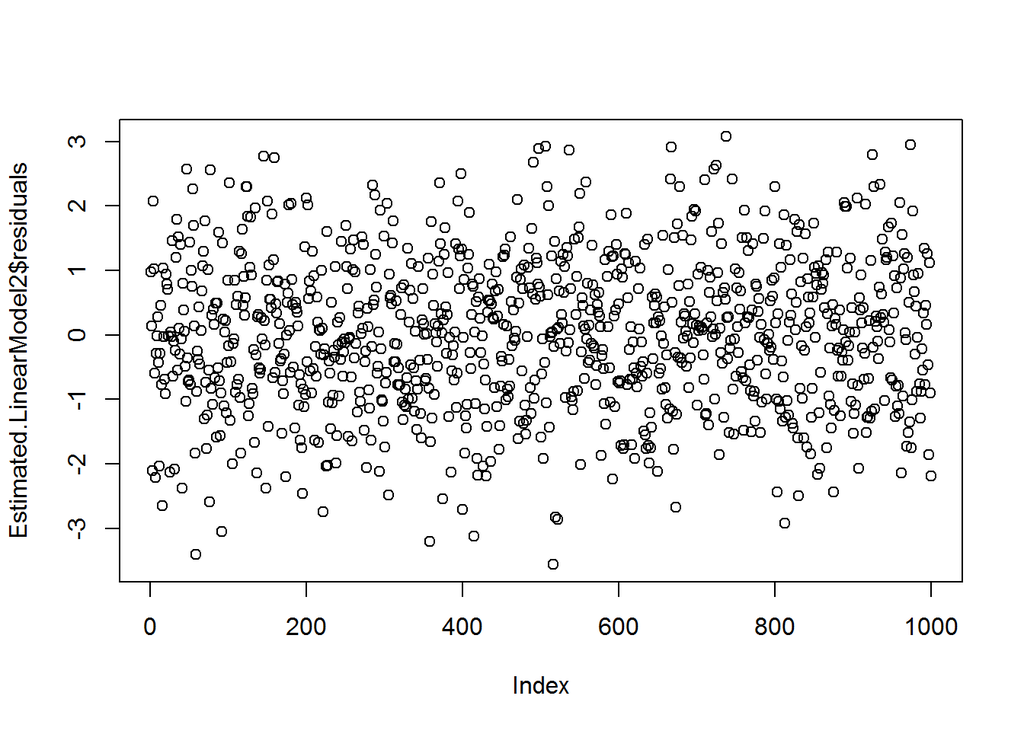

```r
plot(Estimated.LinearModel2$residuals)
```

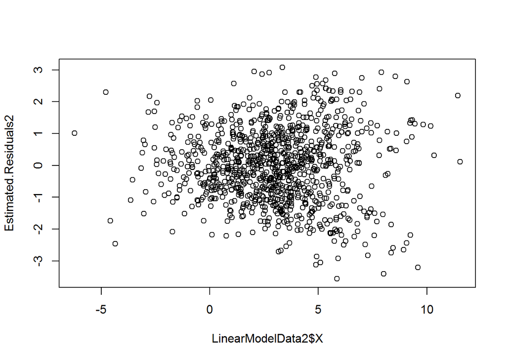

```r
Estimated.Residuals2 <- Estimated.LinearModel2$residuals
plot(LinearModelData2$X, Estimated.Residuals2)
```

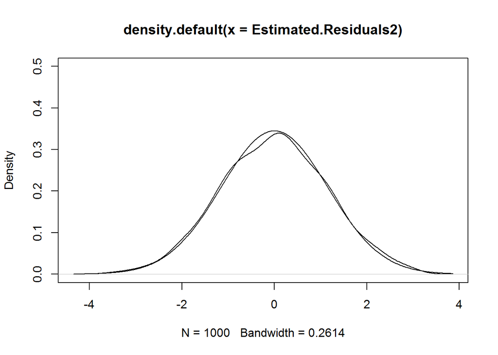

```r
Probability.Density.Residuals2 <- density(Estimated.Residuals2)
plot(Probability.Density.Residuals2, ylim = c(0, 0.5))
lines(Probability.Density.Residuals2$x, dnorm(Probability.Density.Residuals2$x, mean = mean(Estimated.Residuals2), sd = sd(Estimated.Residuals2)))
```

From the residual’s plot we can see that in the middle of the density, there is one more heavy density line. From the density plot we can also see that within a normal curve, there is one part higher than other, which looks like another normal curve appears.

### 4. Try to explain the differences between the two cases

The difference between the two cases are that, in the second case, the two mixed random variable are not clearly seperated. Instead, one random variable with smaller variance is within the other variable with larger variance. It’s difficult to seperate the two.

### 5. Try to guess how the data of the second case were simulated and with what parameters

The second case could be simulated through the similar way as the case. With Bernoulli trial with 0.5 probability for head. Once get a head, take the random variable 1 as randon variable; and if get a tail, take the random variable 2.

The difference is that the two random variables are different from the case 1. One variable with have around mean 0 with larger variance, while the other with mean a little bit above 0, but with smaller variance.